# Purr

Anthony Twesigye

30/07/2021

## https://www.rebeccabarter.com/blog/2019-08-19_purrr/

## Some map functions

### map()

- map(.x, .f) is the main mapping function and returns a list
- map_df(.x, .f) returns a data frame
- map_dbl(.x, .f) returns a numeric (double) vector
- map_chr(.x, .f) returns a character vector
- map_lgl(.x, .f) returns a logical vector

### map2()

### pmap()

```r
my_first_list <- list(my_number = 5,
                      my_vector = c("a", "b", "c"),
                      my_dataframe = data.frame(a = 1:3, b = c("q", "b", "z"), c = c("bananas", "are", "so very great")))
my_first_list
```

```
## $my_number
## [1] 5
##
## $my_vector
## [1] "a" "b" "c"
##
## $my_dataframe
##   a b             c
## 1 1 q       bananas
## 2 2 b           are
## 3 3 z so very great
```

## Simplest usage: repeated looping with map

### map(.x, .f)

```r
addTen <- function(.x) {
  return(.x + 10)
}

# vector
added_values <- map(.x = c(1, 4, 7), .f = addTen)
added_values[[1]]
```

```
## [1] 11
```

```r
added_values_2 <- map(c(1, 4, 7), addTen)

# list
map(list(1, 4, 7), addTen)
```

```
## [[1]]
## [1] 11
##
## [[2]]
## [1] 14
##
## [[3]]
## [1] 17
```

```r
# data frame
map(data.frame(a = 1, b = 4, c = 7), addTen)
```

```
## $a
## [1] 11
##
## $b
## [1] 14
##
## $c
## [1] 17
```

```r
# in case of need of different output
map_dbl(c(1, 4, 7), addTen)
```

```
## [1] 11 14 17
```

```r
map_chr(list(1, 4, 7), addTen)
```

```
## [1] "11.000000" "14.000000" "17.000000"
```

```r
map_df(data.frame(a = 1, b = 4, c = 7), addTen)
```

```
## # A tibble: 1 x 3
##       a     b     c
##   <dbl> <dbl> <dbl>
## 1    11    14    17
```

```r
map_df(c(1, 4, 7), function(.x) {
  return(data.frame(old_number = .x,
                    new_number = addTen(.x)))
})
```

```
##   old_number new_number
## 1          1         11
## 2          4         14
## 3          7         17
```

```r
# Note that in this case, I defined an “anonymous” function as our output for each iteration.

# using ay argument name
map_df(c(1, 4, 7), function(input) {
  return(data.frame(old_number = input,
                    new_number = addTen(input)))
})
```

```
##   old_number new_number
## 1          1         11
## 2          4         14
## 3          7         17
```

```r
# modify(), which is just like the map functions, but always returns an object the same type as the input object
modify(c(1, 4, 7), addTen)
```

```
## [1] 11 14 17
```

```r
modify(list(1, 4, 7), addTen)
```

```
## [[1]]
## [1] 11
##
## [[2]]
## [1] 14
##
## [[3]]
## [1] 17
```

```r
modify(data.frame(1, 4, 7), addTen)
```

```
##   X1 X4 X7
## 1 11 14 17
```

```r
# modify_if(), that only applies the function to elements that satisfy a specific criteria (specified by a “predicate function”, the second argument called .p)
modify_if(.x = list(1, 4, 7),
          .p = function(x) x > 5,
          .f = addTen)
```

```
## [[1]]
## [1] 1
##
## [[2]]
## [1] 4
##
## [[3]]
## [1] 17
```

## The tilde-dot shorthand for functions

To make the code more concise you can use the tilde-dot shorthand for anonymous functions (the functions that you create as arguments of other functions).

The notation works by replacing

```r
function(x) {
  x + 10
}
```

with

```r
~{.x + 10}
```

`~` indicates that you have started an anonymous function, and the argument of the anonymous function can be referred to using `.x` (or simply `.`)

```r
map_dbl(c(1, 4, 7), ~{.x + 10})
```

```
## [1] 11 14 17
```

## gapminder dataset

```r
# to download the data directly:
gapminder_orig <- read.csv("https://raw.githubusercontent.com/swcarpentry/r-novice-gapminder/gh-pages/_episodes_rmd/data/gapminder-FiveYearData.csv")
# define a copy of the original dataset that we will clean and play with
gapminder <- gapminder_orig

dim(gapminder)
```

```
## [1] 1704    6
```

```r
head(gapminder)
```

```
##       country year      pop continent lifeExp gdpPercap
## 1 Afghanistan 1952  8425333      Asia  28.801  779.4453
## 2 Afghanistan 1957  9240934      Asia  30.332  820.8530
## 3 Afghanistan 1962 10267083      Asia  31.997  853.1007
## 4 Afghanistan 1967 11537966      Asia  34.020  836.1971
## 5 Afghanistan 1972 13079460      Asia  36.088  739.9811
## 6 Afghanistan 1977 14880372      Asia  38.438  786.1134
```

```r
# identify the type of each column
gapminder %>% map_chr(class)
```

```
##     country        year         pop   continent     lifeExp   gdpPercap
## "character"   "integer"   "numeric" "character"   "numeric"   "numeric"
```

```r
# number of distinct values in each column
gapminder %>% map_dbl(n_distinct)
```

```
##   country      year       pop continent   lifeExp gdpPercap
##       142        12      1704         5      1626      1704
```

```r
# return a few different summaries of each column in a data frame, you can use map_df()

gapminder %>% map_df(~(data.frame(n_distinct = n_distinct(.x),
                                  class = class(.x))))
```

```
##   n_distinct     class
## 1        142 character
## 2         12   integer
## 3       1704   numeric
## 4          5 character
## 5       1626   numeric
## 6       1704   numeric
```

```r
# you can tell map_df() to include column names using the .id argument of map_df()

gapminder %>% map_df(~(data.frame(n_distinct = n_distinct(.x),
                                  class = class(.x))),
                     .id = "variable")
```

```
##    variable n_distinct     class
## 1   country        142 character
## 2      year         12   integer
## 3       pop       1704   numeric
## 4 continent          5 character
## 5   lifeExp       1626   numeric
## 6 gdpPercap       1704   numeric
```

If you’re having trouble thinking through these map actions, I recommend that you first figure out what the code would be to do what you want for a single element, and then paste it into the map_df() function

For instance, since the first element of the gapminder data frame is the first column, let’s define `.x` in our environment to be this first column.

```r
# take the first element of the gapminder data
.x <- gapminder %>% pluck(1)
# look at the first 6 rows
head(.x)
```

```
## [1] "Afghanistan" "Afghanistan" "Afghanistan" "Afghanistan" "Afghanistan"
## [6] "Afghanistan"
```

```r
# Then, you can create a data frame for this column that contains the number of distinct entries, and the class of the column
data.frame(n_distinct = n_distinct(.x),
           class = class(.x))
```

```
##   n_distinct     class
## 1        142 character
```

```r
# Since this has done what was expected want for the first column, you can paste this code into the map function using the tilde-dot shorthand.
gapminder %>% map_df(~(data.frame(n_distinct = n_distinct(.x),
                                  class = class(.x))),
                     .id = "variable")
```

```
##    variable n_distinct     class
## 1   country        142 character
## 2      year         12   integer
## 3       pop       1704   numeric
## 4 continent          5 character
## 5   lifeExp       1626   numeric
## 6 gdpPercap       1704   numeric
```

## Maps with multiple input objects

The map function that maps over two objects instead of 1 is called `map2()`. The first two arguments are the two objects you want to iterate over, and the third is the function (with two arguments, one for each object).

```r
map2(.x = object1, # the first object to iterate over
     .y = object2, # the second object to iterate over
     .f = plotFunction(.x, .y))
```

```r
continent_year <- gapminder %>% distinct(continent, year)
continent_year
```

[output not shown]

[output cut: 46 more lines]

```r
# extract the continent and year pairs as separate vectors
continents <- continent_year %>% pull(continent) %>% as.character
years <- continent_year %>% pull(year)
```

If you want to use tilde-dot short-hand, the anonymous arguments will be `.x` for the first object being iterated over, and `.y` for the second object being iterated over.

Before jumping straight into the map function, it’s a good idea to first figure out what the code will be for just first iteration (the first continent and the first year, which happen to be Asia in 1952).

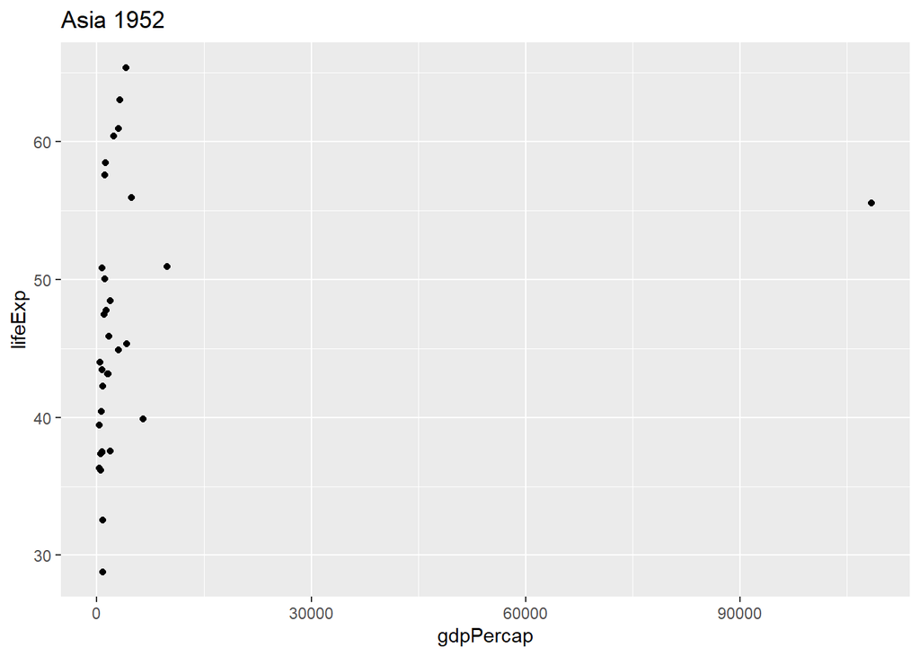

```r
# try to figure out the code for the first example
.x <- continents[1]
.y <- years[1]
# make a scatterplot of GDP vs life expectancy in all Asian countries for 1952
gapminder %>%
  filter(continent == .x,
         year == .y) %>%
  ggplot() +
  geom_point(aes(x = gdpPercap, y = lifeExp)) +
  ggtitle(glue::glue(.x, " ", .y))
```

This seems to have worked. So you can then copy-and-paste the code into the `map2` function

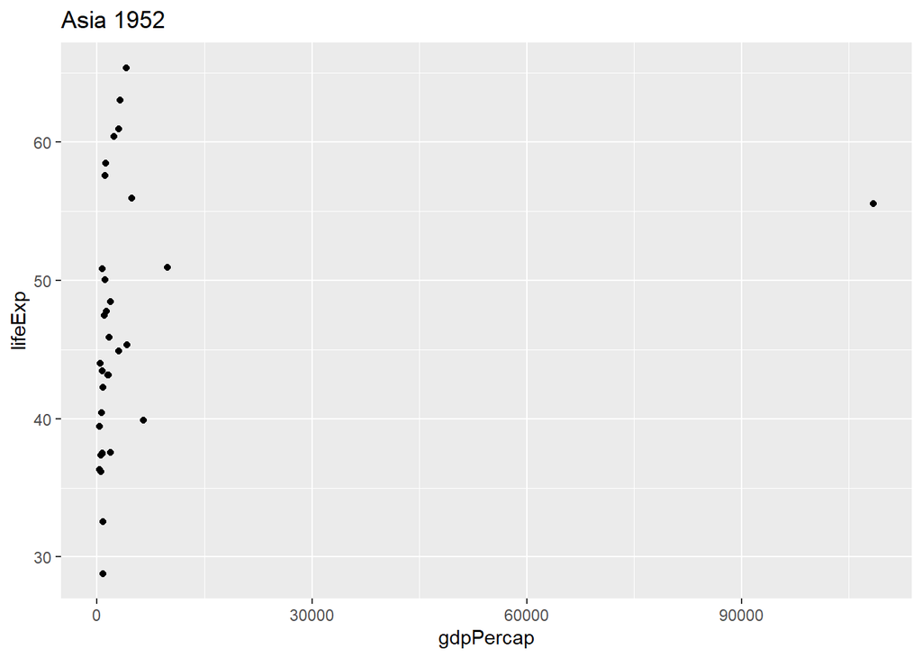

```r
plot_list <- map2(.x = continents,
                  .y = years,
                  .f = ~{
                    gapminder %>%
                      filter(continent == .x,
                             year == .y) %>%
                      ggplot() +
                      geom_point(aes(x = gdpPercap, y = lifeExp)) +
                      ggtitle(glue::glue(.x, " ", .y))
                  })

plot_list[[1]]
```

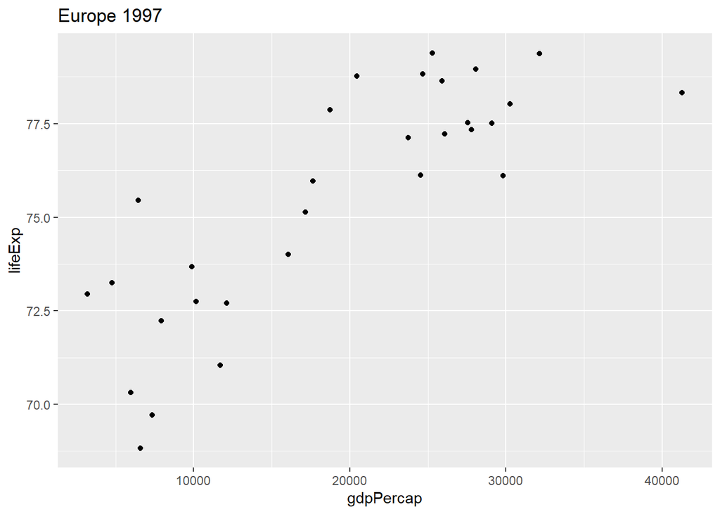

```r
plot_list[[22]]
```

`pmap()` allows you to iterate over an arbitrary number of objects (i.e. more than two)

## List columns and Nested data frames

A tibble can be “nested” where the tibble is essentially split into separate data frames based on a grouping variable, and these separate data frames are stored as entries of a list (that is then stored in the `data` column of the data frame).

```r
gapminder_nested <- gapminder %>%
  group_by(continent) %>%
  nest()
gapminder_nested
```

```
## # A tibble: 5 x 2
## # Groups:   continent [5]
##   continent data
##   <chr>     <list>
## 1 Asia      <tibble [396 x 5]>
## 2 Europe    <tibble [360 x 5]>
## 3 Africa    <tibble [624 x 5]>
## 4 Americas  <tibble [300 x 5]>
## 5 Oceania   <tibble [24 x 5]>
```

```r
gapminder_nested$data[[1]]
```

```
## # A tibble: 396 x 5
##    country      year      pop lifeExp gdpPercap
##    <chr>       <int>    <dbl>   <dbl>     <dbl>
##  1 Afghanistan  1952  8425333    28.8      779.
##  2 Afghanistan  1957  9240934    30.3      821.
##  3 Afghanistan  1962 10267083    32.0      853.
##  4 Afghanistan  1967 11537966    34.0      836.
##  5 Afghanistan  1972 13079460    36.1      740.
##  6 Afghanistan  1977 14880372    38.4      786.
##  7 Afghanistan  1982 12881816    39.9      978.
##  8 Afghanistan  1987 13867957    40.8      852.
##  9 Afghanistan  1992 16317921    41.7      649.
## 10 Afghanistan  1997 22227415    41.8      635.
## # ... with 386 more rows
```

Using dplyr `pluck()` function, this can be written as

```r
gapminder_nested %>%
  # extract the first entry from the data column
  pluck("data", 1)
```

```
## # A tibble: 396 x 5
##    country      year      pop lifeExp gdpPercap
##    <chr>       <int>    <dbl>   <dbl>     <dbl>
##  1 Afghanistan  1952  8425333    28.8      779.
##  2 Afghanistan  1957  9240934    30.3      821.
##  3 Afghanistan  1962 10267083    32.0      853.
##  4 Afghanistan  1967 11537966    34.0      836.
##  5 Afghanistan  1972 13079460    36.1      740.
##  6 Afghanistan  1977 14880372    38.4      786.
##  7 Afghanistan  1982 12881816    39.9      978.
##  8 Afghanistan  1987 13867957    40.8      852.
##  9 Afghanistan  1992 16317921    41.7      649.
## 10 Afghanistan  1997 22227415    41.8      635.
## # ... with 386 more rows
```

```r
# the 5th entry in the data column corresponds to the entire gapminder dataset for Oceania.
gapminder_nested %>%
  pluck("data", 5)
```

```
## # A tibble: 24 x 5
##    country    year      pop lifeExp gdpPercap
##    <chr>     <int>    <dbl>   <dbl>     <dbl>
##  1 Australia  1952  8691212    69.1    10040.
##  2 Australia  1957  9712569    70.3    10950.
##  3 Australia  1962 10794968    70.9    12217.
##  4 Australia  1967 11872264    71.1    14526.
##  5 Australia  1972 13177000    71.9    16789.
##  6 Australia  1977 14074100    73.5    18334.
##  7 Australia  1982 15184200    74.7    19477.
##  8 Australia  1987 16257249    76.3    21889.
##  9 Australia  1992 17481977    77.6    23425.
## 10 Australia  1997 18565243    78.8    26998.
## # ... with 14 more rows
```

You now have the power to use dplyr manipulations on more complex objects that can be stored in a list.

However, since actions such as mutate() are applied directly to the entire column (which is usually a vector, so is fine), we run into issues when we try to mutate a list. For instance, since columns are usually vectors, normal vectorized functions work just fine on them

```r
tibble(vec_col = 1:10) %>%
  mutate(vec_sum = sum(vec_col))
```

```
## # A tibble: 10 x 2
##    vec_col vec_sum
##      <int>   <int>
##  1       1      55
##  2       2      55
##  3       3      55
##  4       4      55
##  5       5      55
##  6       6      55
##  7       7      55
##  8       8      55
##  9       9      55
## 10      10      55
```

but when the column is a list, vectorized functions don’t know what to do with them, and we get an error that says `Error in sum(x) : invalid 'type' (list) of argument`. Try

```r
tibble(list_col = list(c(1, 5, 7),
                       5,
                       c(10, 10, 11))) %>%
  mutate(list_sum = sum(list_col))
```

To apply mutate functions to a list-column, you need to wrap the function you want to apply in a map function.

```r
tibble(list_col = list(c(1, 5, 7),
                       5,
                       c(10, 10, 11))) %>%
  mutate(list_sum = map(list_col, sum))
```

```
## # A tibble: 3 x 2
##   list_col  list_sum
##   <list>    <list>
## 1 <dbl [3]> <dbl [1]>
## 2 <dbl [1]> <dbl [1]>
## 3 <dbl [3]> <dbl [1]>
```

Since `map()` returns a list itself, the `list_sum` column is thus itself a list

```r
tibble(list_col = list(c(1, 5, 7),
                       5,
                       c(10, 10, 11))) %>%
  mutate(list_sum = map(list_col, sum)) %>%
  pull(list_sum)
```

```
## [[1]]
## [1] 13
##
## [[2]]
## [1] 5
##
## [[3]]
## [1] 31
```

What could we do if we wanted it to be a vector? We could use the `map_dbl()` function instead!

```r
tibble(list_col = list(c(1, 5, 7),
                       5,
                       c(10, 10, 11))) %>%
  mutate(list_sum = map_dbl(list_col, sum))
```

```
## # A tibble: 3 x 2
##   list_col  list_sum
##   <list>       <dbl>
## 1 <dbl [3]>       13
## 2 <dbl [1]>        5
## 3 <dbl [3]>       31
```

### Nesting the gapminder data

Think of an individual data frame inside the nested data as `.x`. Again, I will first figure out the code for calculating the mean life expectancy for the first entry of the column. The following code defines `.x` to be the first entry of the data column (this is the data frame for Asia).

```r
# the first entry of the "data" column
.x <- gapminder_nested %>% pluck("data", 1)
.x
```

```
## # A tibble: 396 x 5
##    country      year      pop lifeExp gdpPercap
##    <chr>       <int>    <dbl>   <dbl>     <dbl>
##  1 Afghanistan  1952  8425333    28.8      779.
##  2 Afghanistan  1957  9240934    30.3      821.
##  3 Afghanistan  1962 10267083    32.0      853.
##  4 Afghanistan  1967 11537966    34.0      836.
##  5 Afghanistan  1972 13079460    36.1      740.
##  6 Afghanistan  1977 14880372    38.4      786.
##  7 Afghanistan  1982 12881816    39.9      978.
##  8 Afghanistan  1987 13867957    40.8      852.
##  9 Afghanistan  1992 16317921    41.7      649.
## 10 Afghanistan  1997 22227415    41.8      635.
## # ... with 386 more rows
```

Then to calculate the average life expectancy for Asia, I could write

```r
mean(.x$lifeExp)
```

```
## [1] 60.0649
```

So copy-pasting this into the tilde-dot anonymous function argument of the `map_dbl()` function within `mutate()`, I get what I wanted!

```r
gapminder_nested %>%
  mutate(avg_lifeExp = map_dbl(data, ~{mean(.x$lifeExp)}))
```

```
## # A tibble: 5 x 3
## # Groups:   continent [5]
##   continent data               avg_lifeExp
##   <chr>     <list>                   <dbl>
## 1 Asia      <tibble [396 x 5]>        60.1
## 2 Europe    <tibble [360 x 5]>        71.9
## 3 Africa    <tibble [624 x 5]>        48.9
## 4 Americas  <tibble [300 x 5]>        64.7
## 5 Oceania   <tibble [24 x 5]>         74.3
```

This code iterates through the data frames stored in the `data` column, returns the average life expectancy for each data frame, and concatenates the results into a numeric vector (which is then stored as a column called `avg_lifeExp`).

Hopefully it helped you understand why you need to wrap mutate functions inside map functions when applying them to list columns.

The next exampe will demonstrate how to fit a model separately for each continent, and evaluate it, all within a single tibble. First, I will fit a linear model for each continent and store it as a list-column. If the data frame for a single continent is `.x`, then the model I want to fit is `lm(lifeExp ~ pop + gdpPercap + year, data = .x)` (check for yourself that this does what you expect). So I can copy-past this command into the `map()` function within the `mutate()`

```r
# fit a model separately for each continent
gapminder_nested <- gapminder_nested %>%
  mutate(lm_obj = map(data, ~lm(lifeExp ~ pop + gdpPercap + year, data = .x)))
gapminder_nested
```

```
## # A tibble: 5 x 3
## # Groups:   continent [5]
##   continent data               lm_obj
##   <chr>     <list>             <list>
## 1 Asia      <tibble [396 x 5]> <lm>
## 2 Europe    <tibble [360 x 5]> <lm>
## 3 Africa    <tibble [624 x 5]> <lm>
## 4 Americas  <tibble [300 x 5]> <lm>
## 5 Oceania   <tibble [24 x 5]>  <lm>
```

Where the first linear model (for Asia) is

```r
gapminder_nested %>% pluck("lm_obj", 1)
```

```
##
## Call:
## lm(formula = lifeExp ~ pop + gdpPercap + year, data = .x)
##
## Coefficients:
## (Intercept)          pop    gdpPercap         year
##  -7.833e+02    4.228e-11    2.510e-04    4.251e-01
```

I can then predict the response for the data stored in the data column using the corresponding linear model. So I have two objects I want to iterate over: the data and the linear model object. This means I want to use map2(). When things get a little more complicated I like to have multiple function arguments, so I’m going to use a full anonymous function rather than the tilde-dot shorthand.

```r
# predict the response for each continent
gapminder_nested <- gapminder_nested %>%
  mutate(pred = map2(lm_obj, data, function(.lm, .data) predict(.lm, .data)))
gapminder_nested
```

```
## # A tibble: 5 x 4
## # Groups:   continent [5]
##   continent data               lm_obj pred
##   <chr>     <list>             <list> <list>
## 1 Asia      <tibble [396 x 5]> <lm>   <dbl [396]>
## 2 Europe    <tibble [360 x 5]> <lm>   <dbl [360]>
## 3 Africa    <tibble [624 x 5]> <lm>   <dbl [624]>
## 4 Americas  <tibble [300 x 5]> <lm>   <dbl [300]>
## 5 Oceania   <tibble [24 x 5]>  <lm>   <dbl [24]>
```

And I can then calculate the correlation between the predicted response and the true response, this time using the `map2()_dbl` function since I want the output the be a numeric vector rather than a list of single elements.

```r
# calculate the correlation between observed and predicted response for each continent
gapminder_nested <- gapminder_nested %>%
  mutate(cor = map2_dbl(pred, data, function(.pred, .data) cor(.pred, .data$lifeExp)))
gapminder_nested
```

```
## # A tibble: 5 x 5
## # Groups:   continent [5]
##   continent data               lm_obj pred          cor
##   <chr>     <list>             <list> <list>      <dbl>
## 1 Asia      <tibble [396 x 5]> <lm>   <dbl [396]> 0.723
## 2 Europe    <tibble [360 x 5]> <lm>   <dbl [360]> 0.834
## 3 Africa    <tibble [624 x 5]> <lm>   <dbl [624]> 0.645
## 4 Americas  <tibble [300 x 5]> <lm>   <dbl [300]> 0.779
## 5 Oceania   <tibble [24 x 5]>  <lm>   <dbl [24]>  0.987
```

## Additional purrr functionalities for lists

To demonstrate how to use purrr to manipulate lists, we will split the gapminder dataset into a *list of data frames* (which is kind of like the converse of a data frame containing a list-column). To make sure it’s easy to follow, we will only keep 5 rows from each continent.

```r
set.seed(23489)
gapminder_list <- gapminder %>% split(gapminder$continent) %>%
  map(~sample_n(., 5))
gapminder_list
```

```
## $Africa
##             country year      pop continent lifeExp gdpPercap
## 1            Gambia 1967   439593    Africa  35.857  734.7829
## 2      Sierra Leone 1967  2662190    Africa  34.113 1206.0435
## 3           Namibia 1997  1774766    Africa  58.909 3899.5243
## 4 Equatorial Guinea 1992   387838    Africa  47.545 1132.0550
## 5     Cote d'Ivoire 2002 16252726    Africa  46.832 1648.8008
##
## $Americas
##              country year     pop continent lifeExp gdpPercap
## 1 Dominican Republic 1997 7992357  Americas  69.957  3614.101
## 2        Puerto Rico 1987 3444468  Americas  74.630 12281.342
## 3           Honduras 1992 5077347  Americas  66.399  3081.695
## 4            Uruguay 2007 3447496  Americas  76.384 10611.463
## 5         Costa Rica 1962 1345187  Americas  62.842  3460.937
##
## $Asia
##      country year       pop continent lifeExp gdpPercap
## 1    Lebanon 1967   2186894      Asia  63.870 6006.9830
## 2      Nepal 1962  10332057      Asia  39.393  652.3969
## 3 Yemen Rep. 1992  13367997      Asia  55.599 1879.4967
## 4      India 1972 567000000      Asia  50.651  724.0325
## 5   Cambodia 1952   4693836      Asia  39.417  368.4693
##
## $Europe
##          country year      pop continent lifeExp gdpPercap
## 1 United Kingdom 2002 59912431    Europe  78.471  29479.00
## 2         Greece 1997 10502372    Europe  77.869  18747.70
## 3        Belgium 2002 10311970    Europe  78.320  30485.88
## 4        Croatia 2002  4481020    Europe  74.876  11628.39
## 5    Netherlands 1967 12596822    Europe  73.820  15363.25
##
## $Oceania
##       country year      pop continent lifeExp gdpPercap
## 1   Australia 1982 15184200   Oceania  74.740  19477.01
## 2 New Zealand 1997  3676187   Oceania  77.550  21050.41
## 3 New Zealand 2007  4115771   Oceania  80.204  25185.01
## 4   Australia 2007 20434176   Oceania  81.235  34435.37
## 5 New Zealand 1952  1994794   Oceania  69.390  10556.58
```

### Keep/Discard: select_if for lists

`keep()` only keeps elements of a list that satisfy a given condition, much like `select_if()` selects columns of a data frame that satisfy a given condition.

The following code only keeps the gapminder continent data frames (the elements of the list) that have an average (among the sample of 5 rows) life expectancy of at least 70.

```r
gapminder_list %>%
  keep(~{mean(.x$lifeExp) > 70})
```

```
## $Americas
##              country year     pop continent lifeExp gdpPercap
## 1 Dominican Republic 1997 7992357  Americas  69.957  3614.101
## 2        Puerto Rico 1987 3444468  Americas  74.630 12281.342
## 3           Honduras 1992 5077347  Americas  66.399  3081.695
## 4            Uruguay 2007 3447496  Americas  76.384 10611.463
## 5         Costa Rica 1962 1345187  Americas  62.842  3460.937
##
## $Europe
##          country year      pop continent lifeExp gdpPercap
## 1 United Kingdom 2002 59912431    Europe  78.471  29479.00
## 2         Greece 1997 10502372    Europe  77.869  18747.70
## 3        Belgium 2002 10311970    Europe  78.320  30485.88
## 4        Croatia 2002  4481020    Europe  74.876  11628.39
## 5    Netherlands 1967 12596822    Europe  73.820  15363.25
##
## $Oceania
##       country year      pop continent lifeExp gdpPercap
## 1   Australia 1982 15184200   Oceania  74.740  19477.01
## 2 New Zealand 1997  3676187   Oceania  77.550  21050.41
## 3 New Zealand 2007  4115771   Oceania  80.204  25185.01
## 4   Australia 2007 20434176   Oceania  81.235  34435.37
## 5 New Zealand 1952  1994794   Oceania  69.390  10556.58
```

`discard()` does the opposite of `keep()`: it discards any elements that satisfy your logical condition.

### Reduce

`reduce()` is designed to combine (reduces) all of the elements of a list into a single object by iteratively applying a binary function (a function that takes two inputs)

For instance, applying a reduce function to add up all of the elements of the vector `c(1, 2, 3)` is like doing `sum(sum(1, 2), 3)`: first it applies `sum` to `1` and `2`, then it applies `sum` again to the output of `sum(1, 2)` and `3`

```r
reduce(c(1, 2, 3), sum)
```

```
## [1] 6
```

`accumulate()` also returns the intermediate values.

```r
accumulate(c(1, 2, 3), sum)
```

```
## [1] 1 3 6
```

An example of when `reduce()` might come in handy is when you want to perform many `left_join()`s in a row, or to do repeated `rbinds()` (e.g. to bind the rows of the list back together into a single data frame)

```r
gapminder_list %>%
  reduce(rbind)
```

```
##               country year       pop continent lifeExp  gdpPercap
## 1              Gambia 1967    439593    Africa  35.857   734.7829
## 2        Sierra Leone 1967   2662190    Africa  34.113  1206.0435
## 3             Namibia 1997   1774766    Africa  58.909  3899.5243
## 4   Equatorial Guinea 1992    387838    Africa  47.545  1132.0550
## 5       Cote d'Ivoire 2002  16252726    Africa  46.832  1648.8008
## 6  Dominican Republic 1997   7992357  Americas  69.957  3614.1013
## 7         Puerto Rico 1987   3444468  Americas  74.630 12281.3419
## 8            Honduras 1992   5077347  Americas  66.399  3081.6946
## 9             Uruguay 2007   3447496  Americas  76.384 10611.4630
## 10         Costa Rica 1962   1345187  Americas  62.842  3460.9370
## 11            Lebanon 1967   2186894      Asia  63.870  6006.9830
## 12              Nepal 1962  10332057      Asia  39.393   652.3969
## 13         Yemen Rep. 1992  13367997      Asia  55.599  1879.4967
## 14              India 1972 567000000      Asia  50.651   724.0325
## 15           Cambodia 1952   4693836      Asia  39.417   368.4693
## 16     United Kingdom 2002  59912431    Europe  78.471 29478.9992
## 17             Greece 1997  10502372    Europe  77.869 18747.6981
## 18            Belgium 2002  10311970    Europe  78.320 30485.8838
## 19            Croatia 2002   4481020    Europe  74.876 11628.3890
## 20        Netherlands 1967  12596822    Europe  73.820 15363.2514
## 21          Australia 1982  15184200   Oceania  74.740 19477.0093
## 22        New Zealand 1997   3676187   Oceania  77.550 21050.4138
## 23        New Zealand 2007   4115771   Oceania  80.204 25185.0091
## 24          Australia 2007  20434176   Oceania  81.235 34435.3674
## 25        New Zealand 1952   1994794   Oceania  69.390 10556.5757
```

### Logical statements for lists

Asking logical questions of a list can be done using `every()` and `some()`. For instance to ask whether every continent has average life expectancy greater than 70, you can use `every()`

```r
gapminder_list %>% every(~{mean(.x$life) > 70})
```

```
## [1] FALSE
```

To ask whether some continents have average life expectancy greater than 70, you can use `some()`

```r
gapminder_list %>% some(~{mean(.x$life) > 70})
```

```
## [1] TRUE
```

An equivalent of `%in%` for lists is `has_element()`.

```r
list(1, c(2, 5, 1), "a") %>% has_element("a")
```

```
## [1] TRUE
```

Most of these functions also work on vectors.